# Образование в Канаде

Сергей Беломестных

5 января 2018

## Описание набора данных.

Набор данных про образование в Канаде содержит информацию по специальностям образования уровня [post-secondary](https://en.wikipedia.org/wiki/Higher_education), которые распределены по колледжам и университетам учебным заведениям. Всего существует 60 направлений специальностей.

**Набор данных содержит 592936 специальностей по 1082 направлению в 274 колледжах и университетах Канады.**

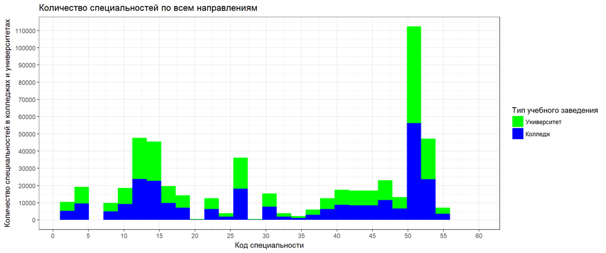

## Постановка задачи.

Работа главным образом посвящена исследованию распределения математических, компьютерных, инженерных и естественно-научных направлений в Канаде.

Работа ставит целью проверить нескольких гипотез:

1. Больше всего специальностей уровня post-secondary в Канаде относится к рассматриваемому набору наук.
2. Математические специальности равномерно распределены по университетам и колледжам.
3. Математические и компьютерные специальности равномерно распределены в группе математических, компьютерных, инженерных и естественно-научных направлений.

## Гипотеза №1. Математика, Физика, Химия, Биология, Инженерия, Информатика.

Все 1082 направления разделены на 60 (коды от 01 до 60), источник для наименований - официальный сайт Statistics Canada http://www.statcan.gc.ca[^1]

Перечень описанных выше наук принадлежит группам: 03, 04, 11, 14, 15, 26, 27, 29, 40, 41, 46, 47, 48, 49 и группе междисциплинарных исследований 30, в которой находятся специальности на стыке наук и технологий, что не исключает попадания в выборку некоторых гуманитарных, медицинских и бизнес специальностей.

| Name_Programm | Code_Programm |
| --- | --- |
| Природные ресурсы и Охрана природы | 3 |
| Архитектура и сопутствующие услуги | 4 |
| Компьютерные и информационные науки и службы поддержки | 11 |
| Инжиниринг | 14 |
| Инженерные технологии и технические области | 15 |
| Биологические и биомедицинские науки | 26 |
| Математика и статистика | 27 |
| Военные технологии и прикладные науки | 29 |
| Междисциплинарные / междисциплинарные исследования | 30 |
| Физические науки | 40 |
| Научные технологии / техники | 41 |
| Строительство | 46 |
| Технологии механики и ремонта / технический персонал | 47 |
| Точное производство | 48 |
| Транспортировка и перемещение материалов | 49 |

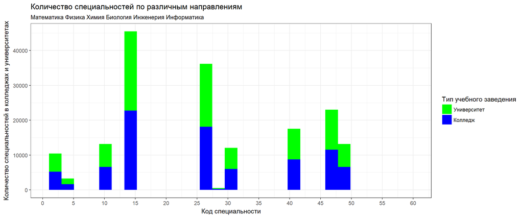

Всего из 592936 специальностей 165812 относятся к рассматриваемым группам, что составляет 28 % от общего числа специальностей. На самом деле немного меньше, потому что в рассмотрение вошли группы междициплинарных специальностей, которые входят во все группы.

| Name | Percent |
| --- | --- |
| Математические, компьютерные, инженерные и естественно-научные направления | 28 |
| Гуманитарные направления(в т.ч. иностранные языки, юриспруденция) | 29 |
| Бизнес, менеджмент, экономика | 8 |
| Медицина | 6 |
| Образование | 22 |
| Сельское хозяйство | 5 |
| Безопасность, военное дело | 2 |
| Физкультура | 1 |

Таким образом, можно сделать следующие заключения:

1. Математические, компьютерные, инженерные и естественно-научные направления не являются наиболее распространенными специальностями в Канаде. Большую долю занимают Гуманитарные направления. Первая гипотеза не верна.
2. Достаточно существенна статистическая ошибка при проведении расчетов, так как междисциплинарные специальности оказывают влияние на все группы. Ошибку при определении доли каждого направления можно оценить в 1.5 %.

## Гипотеза №2. Математические специальности распределены равномерно в колледжах и университетах.

Для проверки гипотезы из набора данных, сформированных только для технических наук была получена информация о количестве математических специальностей в колледжах и вузах.

Проверка проводилась поиском регулярным выражением в названии специальности ключевого слова *math* в любом регистре.

В результате обработки данных было получено, что во всех колледжах и университетах существует по 20 математических специальностей. Таким образом, математические специальности распределены равномерно и гипотеза верна.

## Гипотеза №3. Математические и компьютерные специальности распределены равномерно в рассматриваемой группе наук.

Для проверки гипотезы из набора данных была получена информация о количестве математических и компьютерных специальностей для каждой группы из таблицы 1.

Проверка проводилась поиском регулярным выражением в названии специальности ключевых слов *math* и *computer* без учета регистра.

Области и их код, в которых найдены математические и компьютерные специальнотси приведены в таблице, для остальных областей из рассматриваемых наук число специальностей равно нулю.

| Name | GroupCode | Count |
| --- | --- | --- |
| Компьютерные и информационные науки и службы поддержки | 11 | 8220 |
| Инжиниринг | 14 | 2192 |
| Инженерные технологии и технические области | 15 | 2192 |
| Биологические и биомедицинские науки | 26 | 548 |
| Математика и статистика | 27 | 3836 |
| Междисциплинарные / междисциплинарные исследования | 30 | 1096 |
| Физические науки | 40 | 548 |
| Технологии механики и ремонта / технический персонал | 47 | 548 |

Для этой небольшой выборки был применен тест Шапиро-Уилко и получены слудеющие результаты:

$$W = 0.642442$$
$$P value = 6.4206224\times 10^{-5}$$